# Исследование объявлений о продаже квартир

#### Дорогие и дешевые населенные пункты

Выясним названия 10 населенных пунктом с самым большим количеством объявлений и узнаем какой из них самый дорогой а какой самый дешевый по цене за квадратный метр:

```python
data['price_per_meter'] = data['last_price'] / data['total_area'] #Создаем столбец с стоимостью квадратного метра
cities_value = data.pivot_table(index='locality_name', values='price_per_meter', aggfunc=['mean','count'])#Сводной таблицей группирует данные и находим среднее арифметическое
cities_value.columns = ['Цена за кв. метр', 'Количество объявлений']#Убирает дубликаты названий столбцов
cities_value['Цена за кв. метр'] = cities_value['Цена за кв. метр'].astype('int')#убирает знаки после запятой
cities_value = cities_value.sort_values(by='Количество объявлений',ascending=False).head(10)#Сортирует по количеству объявлений, оставляет 10 больших по количеству объявлений городов
cities_value = cities_value.sort_values(by='Цена за кв. метр',ascending=False)# Сортирует строки по стоимости отдорогой к дешёвой
display(cities_value)
```

| locality_name | Цена за кв. метр | Количество объявлений |
| --- | --- | --- |
| Санкт-Петербург | 112620 | 15518 |
| Пушкин | 103125 | 369 |
| деревня Кудрово | 92473 | 299 |
| поселок Парголово | 90175 | 327 |
| поселок Мурино | 85629 | 552 |
| поселок Шушары | 78551 | 439 |
| Колпино | 75424 | 338 |
| Гатчина | 68746 | 307 |
| Всеволожск | 68654 | 398 |
| Выборг | 58141 | 237 |

Санкт-Петербург ожидаемо самый дорогой, а вот в Выборге стоимость за квадратный метр почти в 2 раза меньше.

```python
data.groupby('locality_name').agg({'balcony':'count', 'last_price':'median'}) \
    .sort_values(by = 'balcony', ascending = False) \
    .head(10)
```

| locality_name | balcony | last_price |
| --- | --- | --- |
| Санкт-Петербург | 15518 | 5500000.0 |
| поселок Мурино | 552 | 3400000.0 |
| поселок Шушары | 439 | 3950000.0 |
| Всеволожск | 398 | 3450000.0 |
| Пушкин | 369 | 5180000.0 |
| Колпино | 338 | 3600000.0 |
| поселок Парголово | 327 | 4100000.0 |
| Гатчина | 307 | 3100000.0 |
| деревня Кудрово | 299 | 3790000.0 |
| Выборг | 237 | 2897000.0 |

#### Стоимость квартиры в Санкт-Петербурге в зависимости от удаленности от центра

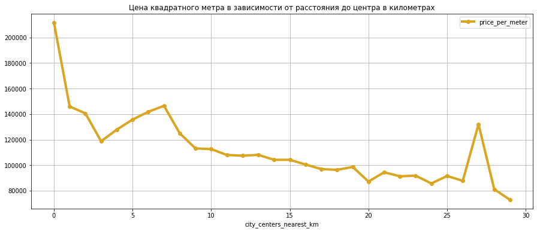

```python
spb_data = data.query('locality_name == "Санкт-Петербург"') #Фильтрует только квартиры в Питере
spb_data = spb_data.pivot_table(index='city_centers_nearest_km', values='price_per_meter', aggfunc='mean')#Сводная таблица средняя цена за квадртный метр сгрупированной по количеству километров от центра
spb_data['price_per_meter'] = spb_data['price_per_meter'].astype('int')
spb_data.plot(style='o-', grid=True, figsize=(15, 6), linewidth=4, color='goldenrod', title='Цена квадратного метра в зависимости от расстояния до центра в километрах')
```

Чем дальше от центра гороода- тем ниже средняя стоимость квадратного метра жилья. На расстоянии в 20км цена падает уже в два раза. А наиболее выгодные квартиры по соотношению цены и расстояния до центра находятся в трех километрах. Выброс на 27км вызван тем, что в таблице мало строк с этим расстоянием.

### Общий вывод

В ходе исследования мною была совершена предварительная обработка данных (удалены пропущенные значения и дубликаты, исправлен тип данных там, где требуется).\ \ Были добавлены новые столбцы с данными цене квадратного метра, день недели публикации, месяце публикации, года публикации, типа этажа и расстоянии до центра в километрах для каждой квартиры.\ \ Изучены основные параметры и и распростроненность их значений. Построены графики. Сделаны промежуточные выводы и наблюдения.\ \ Исследована скорость продажи квартир. Из предоставленных данных сделан вывод что быстрыми можно считать продажи быстрее полутора месяцев а слишком долгими дольше восьми месяцев.\ \ Проанализированны факторы, влиющие на стоимость, главными и важнейшим из которых оказалась площадь квартиры и вытекающие из нее факторы, такие как количетсво комнат, жилая площадь, площадь кухни. Помимо этого, мною было замечено, что на стоимость также влияют близость квартиры к центру, высота потолков, этаж квартиры.\ \ Из десяти самых крупных по количеству объявлений найдены самые дорогие по цене за квадратный метр. Ими оказались Санкт-Петербург, Пушкин и деревня Кудрово.\ \ Исследованна и подтверждена обратная зависимость цены за квадратный метр в зависимости от удаленности от центра города.\ \ Таким образом, можно сделать вывод, что самая дорогая квартира должна быть в центре, иметь площадь более 70 метров, иметь более 7 комнат, не находиться на первом и последнем этажах, иметь высоту потолков более 2.6 метров а объявление о продаже должно быть размещено в начале недели и в любой мессяц кроме июня.